# Raskind Neuron

Данные: информация о количестве n-gram нейронов в модели ruGPT(https://huggingface.co/ai-forever/rugpt3small_based_on_gpt2) на самых частых 1,2 и 3-граммах (информация о частоте - НКРЯ). Подробнее о n-gram нейронах - в статье(https://arxiv.org/pdf/2309.04827) Код для создания пробингового датасета и сбора активаций - в репозитории

```r
library(dplyr)
library(tidyverse)

library(ggplot2)
```

Гипотеза H_0: Слой, на котором расположен соответствующий 1-gram нейрон, не связан с частотностью слова Гипотеза H_1: Существует корреляция между слоем с 1-gram нейроном и частотой слова

Импортируем данные по 1-gram активациям

```r
unigram <- read.csv("unigr_layers.csv", encoding = "UTF-8")
layers <- as.vector(unigram$layer)
ranks <- as.vector(unigram$rank)
```

Визуализируем распределение

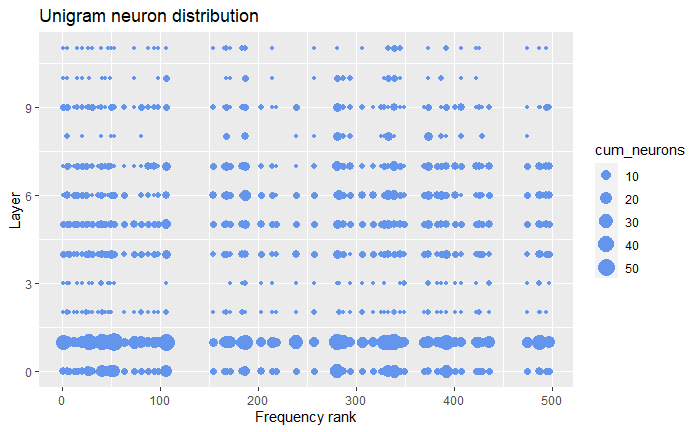

```r
agg_table <- unigram %>% group_by(layer, rank) %>%
  summarise(cum_neurons=n())
ggplot(data = agg_table, aes(x = rank, y = layer)) +
  geom_point(aes(size = cum_neurons), color = "cornflowerblue") +
  labs(title = "Unigram neuron distribution",
       x = "Frequency rank",
       y = "Layer")
```

```r
cor.test(layers, ranks, method = 'spearman')
```

```
    Spearman's rank correlation rho

data:  layers and ranks
S = 4431276311, p-value = 3.687e-08
alternative hypothesis: true rho is not equal to 0
sample estimates:
       rho
0.09883423
```

```r
cor.test(layers, ranks, method = 'kendall')
```

```
    Kendall's rank correlation tau

data:  layers and ranks
z = 5.4586, p-value = 4.799e-08
alternative hypothesis: true tau is not equal to 0
sample estimates:
       tau
0.07204353
```

Гипотеза H_0: Слой, на котором расположен соответствующий 2-gram нейрон, не связан с частотностью слова Гипотеза H_1: Существует корреляция между слоем с 2-gram нейроном и частотой слова

Импортируем данные по 2-gram активациям

```r
bigram <- read.csv("bigr_layers.csv", encoding = "UTF-8")
b_layers <- as.vector(bigram$layer)
b_ranks <- as.vector(bigram$rank)
```

Визуализируем распределение

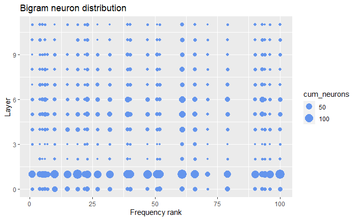

```r
agg_table <- bigram %>% group_by(layer, rank) %>%
  summarise(cum_neurons=n())
ggplot(data = agg_table, aes(x = rank, y = layer)) +
  geom_point(aes(size = cum_neurons), color = "cornflowerblue") +
  labs(title = "Bigram neuron distribution",
       x = "Frequency rank",
       y = "Layer")
```

```r
cor.test(b_layers, b_ranks, method = 'spearman')
```

```
    Spearman's rank correlation rho

data:  b_layers and b_ranks
S = 1.5322e+10, p-value = 0.0002317
alternative hypothesis: true rho is not equal to 0
sample estimates:
       rho
0.05427018
```

```r
cor.test(b_layers, b_ranks, method = 'kendall')
```

```
    Kendall's rank correlation tau

data:  b_layers and b_ranks
z = 3.679, p-value = 0.0002342
alternative hypothesis: true tau is not equal to 0
sample estimates:
       tau
0.04051152
```

Гипотеза H_0: Слой, на котором расположен соответствующий 3-gram нейрон, не связан с частотностью слова Гипотеза H_1: Существует корреляция между слоем с 3-gram нейроном и частотой слова

Импортируем данные по 3-gram активациям

```r
trigram <- read.csv("trigr_layers.csv", encoding = "UTF-8")
t_layers <- as.vector(trigram$layer)
t_ranks <- as.vector(trigram$rank)
```

Визуализируем распределение

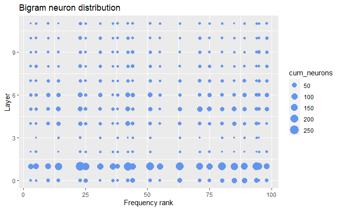

```r
agg_table <- trigram %>% group_by(layer, rank) %>%
  summarise(cum_neurons=n())
ggplot(data = agg_table, aes(x = rank, y = layer)) +
  geom_point(aes(size = cum_neurons), color = "cornflowerblue") +
  labs(title = "Bigram neuron distribution",
       x = "Frequency rank",
       y = "Layer")
```

```r
cor.test(t_layers, t_ranks, method = 'spearman')
```

```
    Spearman's rank correlation rho

data:  t_layers and t_ranks
S = 4.6604e+10, p-value = 0.009082
alternative hypothesis: true rho is not equal to 0
sample estimates:
        rho
-0.03243294
```

```r
cor.test(t_layers, t_ranks, method = 'kendall')
```

```
    Kendall's rank correlation tau

data:  t_layers and t_ranks
z = -2.612, p-value = 0.009
alternative hypothesis: true tau is not equal to 0
sample estimates:
        tau
-0.02443652
```

Хотелось бы также понять, зависит ли слой n-gram нейрона от того, насколько n-gram он ориентирован. В идеале можно было бы провести дисперсионный анализ, но, так как все величины дискретны, ANOVA неприменим. Воспользуемся тем, что n-граммы естественным образом организуются в ранги, за которыми теоретически есть языковая интуиция (чем больше n-грамма, тем сложнее оборот, и тем дальше в нейросети его надо анализировать)

```r
cum_layers <- c(layers, b_layers, t_layers)
```

```r
uni <- rep(1, length(layers))
bi <- rep(2, length(b_layers))
tri <- rep(3, length(t_layers))
cum = c(uni, bi, tri)
```

```r
cor.test(cum_layers, cum, method = 'kendall')
```

```
    Kendall's rank correlation tau

data:  cum_layers and cum
z = 0.1458, p-value = 0.8841
alternative hypothesis: true tau is not equal to 0
sample estimates:
        tau
0.001039859
```

Выводы:

С увеличением величны n-грам уменьшается предполагаемая зависимость частоты токена и и слоя, на котором он явно обрабатывается

C другой стороны, место обработки самой n-граммы статистически значимо не кореллирует с длиной самой n-граммы. Возможно, это связано с тем, какую роль выполняют активирующиеся нейроны в обработке последовательности.